# Data generation

This vignette shows how to build stochastic models, combine them with `+`, generate data, and plot the results.

```r
library(gmwmx2)
set.seed(123)
```

# Available models

You can build a single stochastic process with any of the following model constructors:

- `wn()` (white noise)
- `ar1()` (AR(1))
- `pl()` (power-law)
- `matern()` (Matérn)
- `rw()` (random walk)
- `flicker()` (flicker)

Each constructor returns a `time_series_model` object that can be plotted or combined with others using `+`.

# Stochastic models

## White noise

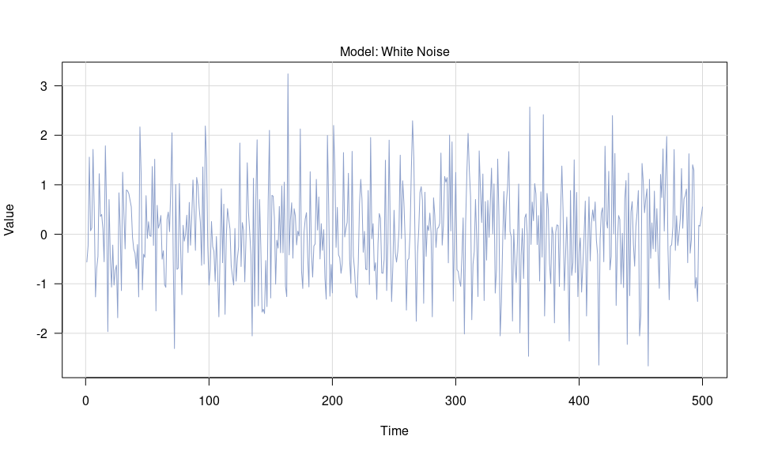

```r
model_wn <- wn(sigma2 = 1)
series_wn <- generate(model_wn, n = 500)
plot(series_wn)
```

The generated object is a `generated_time_series` with a numeric series in `$series`:

```r
head(series_wn$series)
```

```
## [1] -0.56047565 -0.23017749  1.55870831  0.07050839  0.12928774  1.71506499
```

## AR(1)

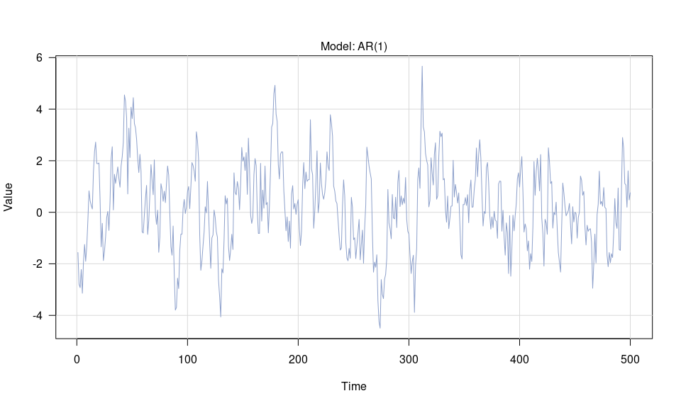

```r
model_ar1 <- ar1(phi = 0.8, sigma2 = 1)
series_ar1 <- generate(model_ar1, n = 500)
plot(series_ar1)
```

## Power-law

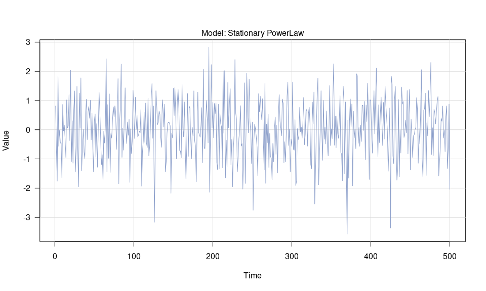

```r
model_pl <- pl(kappa = 0.3, sigma2 = 1)
series_pl <- generate(model_pl, n = 500)
plot(series_pl)
```

## Matérn

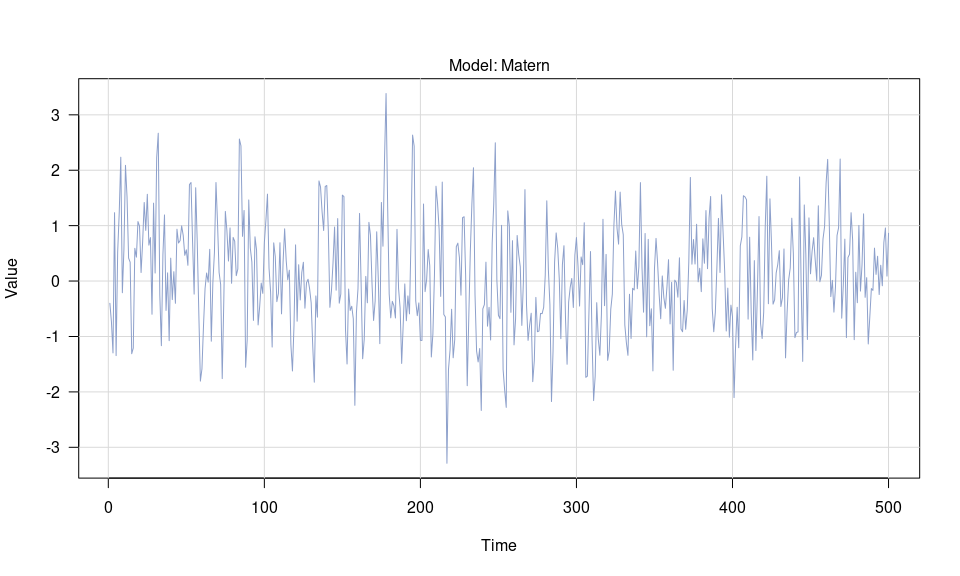

```r
model_matern <- matern(sigma2 = 1, lambda = 1, alpha=1)
series_matern <- generate(model_matern, n = 500)
plot(series_matern)
```

## Random walk

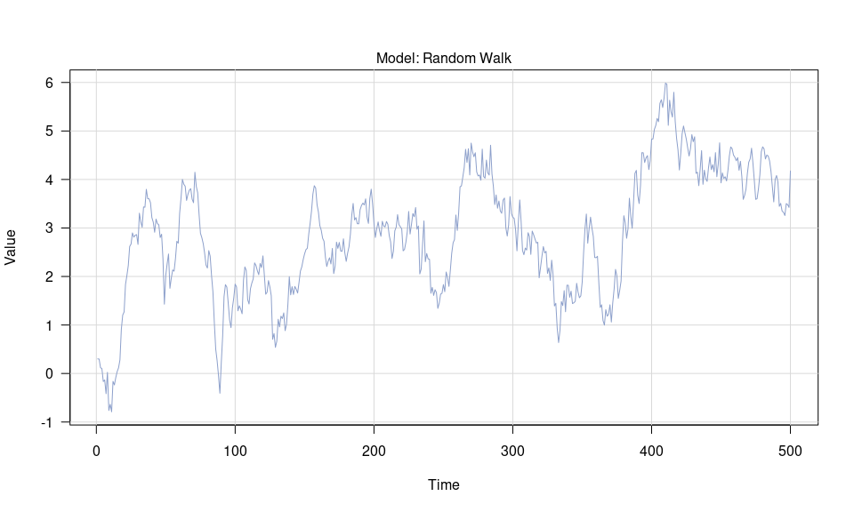

```r
model_rw <- rw(sigma2 = 0.1)
series_rw <- generate(model_rw, n = 500)
plot(series_rw)
```

## Flicker

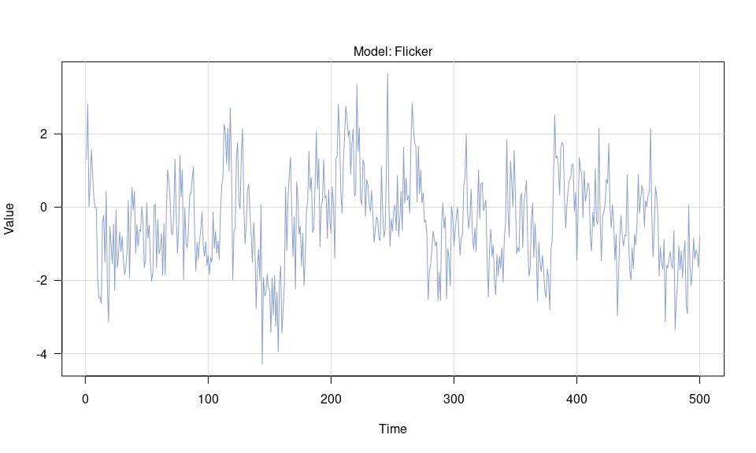

```r
model_fl <- flicker(sigma2 = 1)
series_fl <- generate(model_fl, n = 500)
plot(series_fl)
```

# Reproducible generation

You can set a random seed before calling `generate()`, or pass a seed directly to `generate()`, to make the output deterministic. Using the same seed and model parameters produces the exact same time series.

```r
model_wn <- wn(sigma2 = 1)

set.seed(1234)
series_a <- generate(model_wn, n = 100)

series_b <- generate(model_wn, n = 100, seed = 1234)
series_c <- generate(model_wn, n = 100, seed = 4321)

all.equal(series_a$series, series_b$series)
```

```
## [1] TRUE
```

```r
all.equal(series_a$series, series_c$series)
```

```
## [1] "Mean relative difference: 1.310458"
```

# Composite models (sum of processes)

Use `+` to build a composite model from multiple stochastic processes. The result is a `sum_model` that can be passed to `generate()`.

```r
model_wn_ar1 <- wn(sigma2 = 1) + ar1(phi = 0.8, sigma2 = 0.5)
class(model_wn_ar1)
```

```
## [1] "sum_model"
```

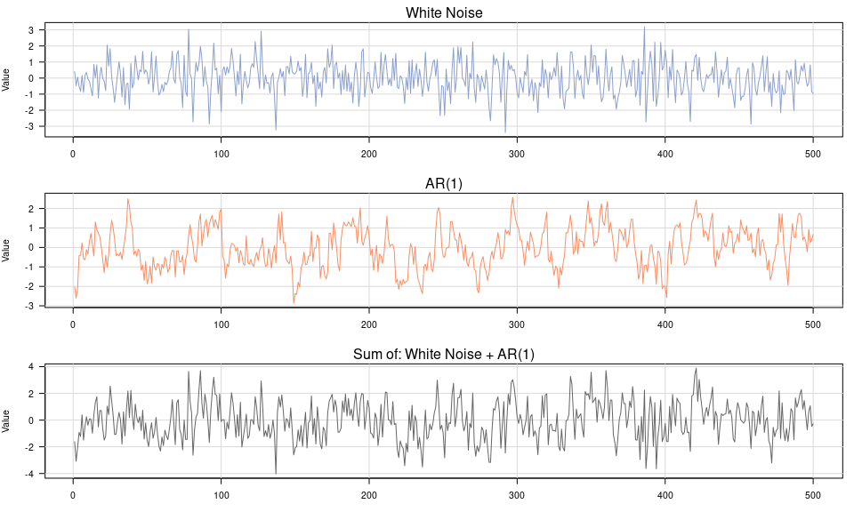

```r
series_wn_ar1 <- generate(model_wn_ar1, n = 500)
plot(series_wn_ar1)
```

The composite output is a `generated_composite_model_time_series` with:

- `series` (the total sum)
- `components` (a list of each component series)
- `n` (length of the series)
- `model` (names of each component)
- `parameters` (parameters of each component)

```r
names(series_wn_ar1)
```

```
## [1] "series"     "components" "n"          "model"      "parameters"
```